# lab8 Assignment

Somnath Mukherjee

March 24, 2019

### Lab set-up

```r
#read input file
#' @sep="" because the columns are seperated by 'space'
Expenditure = read.table(here('lab8','data',"data8.txt"), header = TRUE)
str(Expenditure) # get a structure (description) of your dataset
```

```
## 'data.frame':    48 obs. of  8 variables:
##  $ EX   : int  256 275 327 297 256 312 374 257 257 336 ...
##  $ ECAB : num  85.5 94.3 87 107.5 94.9 ...
##  $ MET  : num  19.7 17.7 0 85.2 86.2 77.6 85.5 78.9 77.9 68.8 ...
##  $ GROW : num  6.9 14.7 3.7 10.2 1 25.4 12.9 25.5 7.8 39.9 ...
##  $ YOUNG: num  29.6 26.4 28.5 25.1 25.3 25.2 24 24.8 25.7 26.4 ...
##  $ OLD  : num  11 11.2 11.2 11.1 10.4 9.6 10.1 9.2 10 8 ...
##  $ WEST : int  0 0 0 0 0 0 0 0 0 0 ...
##  $ STATE: Factor w/ 48 levels "AL","AR","AZ",..: 19 28 44 17 37 6 32 29 36 7 ...
```

### Question 1: Describe the trend in the scatterplot of the raw data: what is the relationship between variables EX and MET?

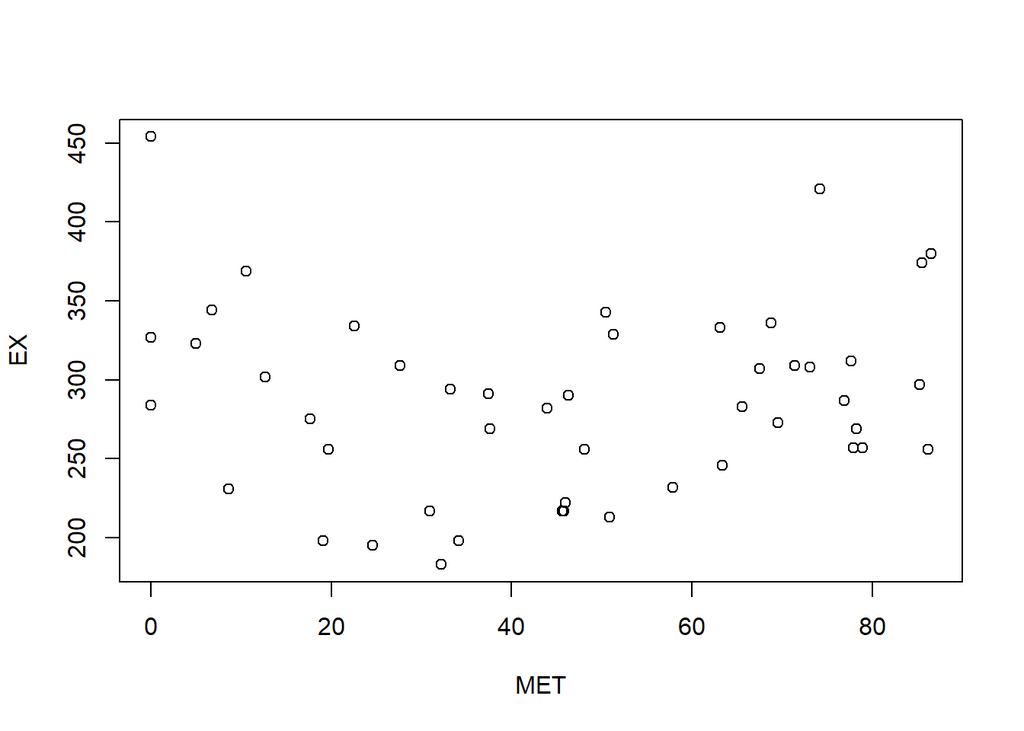

```r
with(Expenditure, plot(MET, EX)) # Plot model variables
```

Based on the scatterplot above, the relationship between variables EX and MET does not appear to be linear. It appears to have a curvature with a bowl shape.

### Question 2: Fit a polynomial regression model with cubic term of MET. When you decide whether the cubic term and quadratic term should be included in the model, do you use the Type I SS or Type II SS? Why?

```r
#' Use the identity function @I() to create polynomial terms
cubicModel <- lm(EX ~ MET + I(MET^2) + I(MET^3), data=Expenditure)
options(scipen=999) # prevents R from reporting numbers with scientific notation
summary(cubicModel)
```

```
##
## Call:
## lm(formula = EX ~ MET + I(MET^2) + I(MET^3), data = Expenditure)
##
## Residuals:
##     Min      1Q  Median      3Q     Max
## -74.374 -41.995  -3.089  39.012 114.868
##
## Coefficients:
##                Estimate  Std. Error t value             Pr(>|t|)
## (Intercept) 358.3739851  24.6756266  14.523 < 0.0000000000000002 ***
## MET          -7.5870688   2.5328744  -2.995              0.00449 **
## I(MET^2)      0.1577084   0.0697934   2.260              0.02885 *
## I(MET^3)     -0.0008753   0.0005312  -1.648              0.10651
## ---
## Signif. codes:  0 '***' 0.001 '**' 0.01 '*' 0.05 '.' 0.1 ' ' 1
##
## Residual standard error: 51.65 on 44 degrees of freedom
## Multiple R-squared:  0.2775, Adjusted R-squared:  0.2282
## F-statistic: 5.632 on 3 and 44 DF,  p-value: 0.002345
```

Based on the F-statistics p-value: 0.002345 < 0.05, overall our model is significant.  
The parameter estimates can be found in the table above under ‘Estimate’ column.

```r
#' Extract Type I SS
anova(cubicModel)
```

```
## Analysis of Variance Table
##
## Response: EX
##           Df Sum Sq Mean Sq F value    Pr(>F)
## MET        1    332     332  0.1246 0.7257742
## I(MET^2)   1  37504   37504 14.0572 0.0005141 ***
## I(MET^3)   1   7245    7245  2.7154 0.1065086
## Residuals 44 117390    2668
## ---
## Signif. codes:  0 '***' 0.001 '**' 0.01 '*' 0.05 '.' 0.1 ' ' 1
```

As we are using polynomial regression we should use TYPE-1 SS to decide whether the cubic term and quadratic term should be included in the model. When fitting polynomial regression models, if a particular model term is significant, all terms of lower order should be assumed significant and retained in the regression model. For this reason, the sequentially adjusted Type I Sums of Squares should be used when one attempts to test whether a polynomial model is as good as the one with a higher order term.

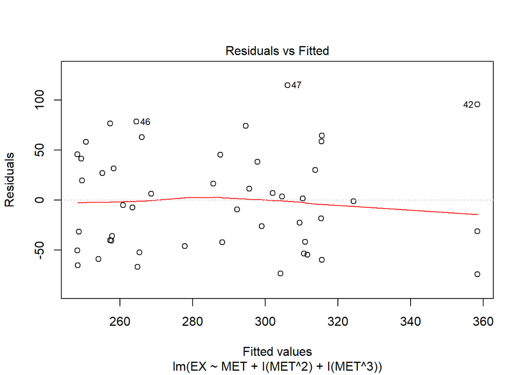

```r
#' plot fitted values against model residuals
plot(cubicModel, which=1)
```

```r
#' Tests the assumption of the normality of the residuals
ols_test_normality(cubicModel)
```

```
## -----------------------------------------------
##        Test             Statistic       pvalue
## -----------------------------------------------
## Shapiro-Wilk              0.9562         0.0708
## Kolmogorov-Smirnov        0.1099         0.5699
## Cramer-von Mises          4.0208         0.0000
## Anderson-Darling          0.6237         0.0984
## -----------------------------------------------
```

### Question 3: Is the cubic effect significant? How about quadratic and linear effects?

```r
quadModel <- lm(EX ~ MET + I(MET^2), data=Expenditure)
summary(quadModel)
```

```
##
## Call:
## lm(formula = EX ~ MET + I(MET^2), data = Expenditure)
##
## Residuals:
##     Min      1Q  Median      3Q     Max
## -81.914 -38.708   2.128  35.003 123.031
##
## Coefficients:
##              Estimate Std. Error t value             Pr(>|t|)
## (Intercept) 336.53030   21.20564  15.870 < 0.0000000000000002 ***
## MET          -3.81156    1.10018  -3.464             0.001178 **
## I(MET^2)      0.04436    0.01206   3.680             0.000622 ***
## ---
## Signif. codes:  0 '***' 0.001 '**' 0.01 '*' 0.05 '.' 0.1 ' ' 1
##
## Residual standard error: 52.63 on 45 degrees of freedom
## Multiple R-squared:  0.2329, Adjusted R-squared:  0.1988
## F-statistic: 6.831 on 2 and 45 DF,  p-value: 0.002567
```

```r
#' Extract Type I SS
anova(quadModel)
```

```
## Analysis of Variance Table
##
## Response: EX
##           Df Sum Sq Mean Sq F value    Pr(>F)
## MET        1    332     332   0.120 0.7306134
## I(MET^2)   1  37504   37504  13.541 0.0006216 ***
## Residuals 45 124635    2770
## ---
## Signif. codes:  0 '***' 0.001 '**' 0.01 '*' 0.05 '.' 0.1 ' ' 1
```

Fitting a Linear Regression Model with a linear term of MET.

```r
linModel <- lm(EX ~ MET, data=Expenditure)
summary(linModel)
```

```
##
## Call:
## lm(formula = EX ~ MET, data = Expenditure)
##
## Residuals:
##      Min       1Q   Median       3Q      Max
## -102.267  -36.535   -0.384   40.776  171.912
##
## Coefficients:
##              Estimate Std. Error t value            Pr(>|t|)
## (Intercept) 282.08773   17.13797  16.460 <0.0000000000000002 ***
## MET           0.09873    0.32147   0.307                0.76
## ---
## Signif. codes:  0 '***' 0.001 '**' 0.01 '*' 0.05 '.' 0.1 ' ' 1
##
## Residual standard error: 59.37 on 46 degrees of freedom
## Multiple R-squared:  0.002046,   Adjusted R-squared:  -0.01965
## F-statistic: 0.09432 on 1 and 46 DF,  p-value: 0.7601
```

```r
#' Extract Type I SS
anova(linModel)
```

```
## Analysis of Variance Table
##
## Response: EX
##           Df Sum Sq Mean Sq F value Pr(>F)
## MET        1    332   332.5  0.0943 0.7601
## Residuals 46 162139  3524.8
```

### Question 4: Based on your answers to the above questions and the SAS or R output, which polynomial model do you consider the best? Write down the polynomial model with the estimated coefficient values. Do you keep the linear term in the model? Why?

Based on my analysis for question-3, I will consider the quadratic polynomial model to be best.  
Our model is:  
EX_predicted = 336.53 - 3.81156*MET + 0.04436*MET^2

Yes, we do keep the linear term in the model.When fitting polynomial regression models, if a particular model term is significant, all terms of lower order should be assumed significant and retained in the regression model as we use sequentially adjusted Type I Sums of Squares while fitting the model.

### Question 5: Now assume that there is a state where 80 percent of its residents live in standard metropolitan areas. Use the best model to predict the per capita public expenditure of this state. Is there any problem in doing so?

```r
predict(quadModel,data.frame(MET = 80),interval="prediction") #confidence for fitted at 95%
```

```
##        fit      lwr      upr
## 1 315.5398 205.8031 425.2765
```

```r
range(Expenditure$MET)
```

```
## [1]  0.0 86.5
```

If we observe the range of values for MET in given dataset, we can conclude that 80 falls within the range. Hence there should not be any issue with the predicted value.  
However, extrapolation outside the range of the fitted experimental data is untenable, and should not be attempted.